# Data Analysis Assignment #1 (50 points total)

Tika, Valon

R markdown is a plain-text file format for integrating text and R code, and creating transparent, reproducible and interactive reports. An R markdown file (.Rmd) contains metadata, markdown and R code “chunks,”" and can be “knit” into numerous output types. Answer the test questions by adding R code to the fenced code areas below each item. There are questions that require a written answer that also need to be answered. Enter your comments in the space provided as shown below:

*Answer: (Enter your answer here.)*

Once completed, you will “knit” and submit the resulting .html document and the .Rmd file. The .html will present the output of your R code and your written answers, but your R code will not appear. Your R code will appear in the .Rmd file. The resulting .html document will be graded and a feedback report returned with comments. Points assigned to each item appear in this template.

**Before proceeding, look to the top of the .Rmd for the (YAML) metadata block, where the *title*, *author* and *output* are given. Please change *author* to include your name, with the format ‘lastName, firstName.’ Do not change the statement a <- TRUE.**

If you encounter issues with knitting the .html, please send an email via Canvas to your TA.

Each code chunk is delineated by six (6) backticks; three (3) at the start and three (3) at the end. After the opening ticks, arguments are passed to the code chunk and in curly brackets. **Please do not add or remove backticks, or modify the arguments or values inside the curly brackets.** An example code chunk is included here:

```r
# Comments are included in each code chunk, simply as prompts

#...R code placed here

#...R code placed here
```

R code only needs to be added inside the code chunks for each assignment item. However, there are questions that follow many assignment items. Enter your answers in the space provided. An example showing how to use the template and respond to a question follows.

**Example Problem with Solution:**

Use *rbinom()* to generate two random samples of size 10,000 from the binomial distribution. For the first sample, use p = 0.45 and n = 10. For the second sample, use p = 0.55 and n = 10. Convert the sample frequencies to sample proportions and compute the mean number of successes for each sample. Present these statistics.

```r
set.seed(123)
sample.one <- table(rbinom(10000, 10, 0.45)) / 10000
sample.two <- table(rbinom(10000, 10, 0.55)) / 10000

successes <- seq(0, 10)

round(sum(sample.one*successes), digits = 1) # [1] 4.5
```

```
## [1] 4.5
```

```r
round(sum(sample.two*successes), digits = 1) # [1] 5.5
```

```
## [1] 5.5
```

**Question: How do the simulated expectations compare to calculated binomial expectations?**

*Answer: The calculated binomial expectations are 10(0.45) = 4.5 and 10(0.55) = 5.5. After rounding the simulated results, the same values are obtained.*

Submit both the .Rmd and .html files for grading. You may remove the instructions and example problem above, but do not remove the YAML metadata block or the first, “setup” code chunk. Address the steps that appear below and answer all the questions. Be sure to address each question with code and comments as needed. You may use either base R functions or ggplot2 for the visualizations.

The following code chunk will (a) load the ggplot2 and gridExtra packages, assuming each has been installed on your machine, (b) read-in the abalones dataset, defining a new data frame, “mydata,” (c) return the structure of that data frame, and (d) calculate new variables, VOLUME and RATIO. If either package has not been installed, you must do so first via *install.packages()*; e.g. *install.packages(“ggplot2”)*. You will also need to download the abalones.csv from the course site to a known location on your machine.

```
## 'data.frame':    1036 obs. of  8 variables:
##  $ SEX   : Factor w/ 3 levels "F","I","M": 2 2 2 2 2 2 2 2 2 2 ...
##  $ LENGTH: num  5.57 3.67 10.08 4.09 6.93 ...
##  $ DIAM  : num  4.09 2.62 7.35 3.15 4.83 ...
##  $ HEIGHT: num  1.26 0.84 2.205 0.945 1.785 ...
##  $ WHOLE : num  11.5 3.5 79.38 4.69 21.19 ...
##  $ SHUCK : num  4.31 1.19 44 2.25 9.88 ...
##  $ RINGS : int  6 4 6 3 6 6 5 6 5 6 ...
##  $ CLASS : Factor w/ 5 levels "A1","A2","A3",..: 1 1 1 1 1 1 1 1 1 1 ...
```

(1)(a) (1 point) Use *summary()* to obtain and present descriptive statistics from mydata.

```
##  SEX         LENGTH           DIAM            HEIGHT
##  F:326   Min.   : 2.73   Min.   : 1.995   Min.   :0.525
##  I:329   1st Qu.: 9.45   1st Qu.: 7.350   1st Qu.:2.415
##  M:381   Median :11.45   Median : 8.925   Median :2.940
##          Mean   :11.08   Mean   : 8.622   Mean   :2.947
##          3rd Qu.:13.02   3rd Qu.:10.185   3rd Qu.:3.570
##          Max.   :16.80   Max.   :13.230   Max.   :4.935
##      WHOLE             SHUCK              RINGS        CLASS
##  Min.   :  1.625   Min.   :  0.5625   Min.   : 3.000   A1:108
##  1st Qu.: 56.484   1st Qu.: 23.3006   1st Qu.: 8.000   A2:236
##  Median :101.344   Median : 42.5700   Median : 9.000   A3:329
##  Mean   :105.832   Mean   : 45.4396   Mean   : 9.993   A4:188
##  3rd Qu.:150.319   3rd Qu.: 64.2897   3rd Qu.:11.000   A5:175
##  Max.   :315.750   Max.   :157.0800   Max.   :25.000
##      VOLUME            RATIO
##  Min.   :  3.612   Min.   :0.06734
##  1st Qu.:163.545   1st Qu.:0.12241
##  Median :307.363   Median :0.13914
##  Mean   :326.804   Mean   :0.14205
##  3rd Qu.:463.264   3rd Qu.:0.15911
##  Max.   :995.673   Max.   :0.31176
```

**Question (1 point): Briefly discuss the variable types and distributional implications such as potential skewness and outliers.**

(1)(b) (1 point) Generate a table of counts using SEX and CLASS. Add margins to this table (Hint: There should be 15 cells in this table plus the marginal totals. Apply *table()* first, then pass the table object to *addmargins()* (Kabacoff Section 7.2 pages 144-147)). Lastly, present a barplot of these data.

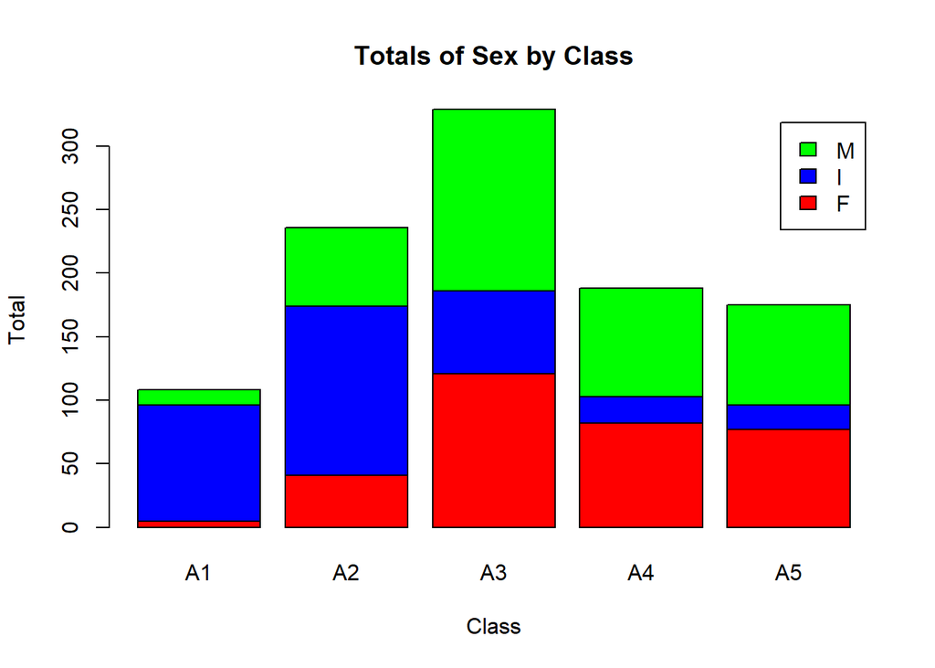

**Question (1 point): Discuss the sex distribution of abalones. What stands out about the distribution of abalones by CLASS?**

*Answer: it seems as though the ratio of males to females across all 5 classes seem relatively close in comparison to one another. Infants, though, seem to take up more of classes A1 and A2, and decrease drastically in proportion as we look at classes A3, A4 and A5. A3 seems to be where most of the Abalones are categorized, relative to the distribution of classes. Most of the infants, though, seem to be in class A2.*

(1)(c) (1 point) Select a simple random sample of 200 observations from “mydata” and identify this sample as “work”. Use *set.seed(123)* prior to drawing this sample. Do not change the number 123. (If you must draw another sample from mydata, it is imperative that you start with *set.seed(123)*, otherwise your second sample will not duplicate your first sample or the “work” sample used for grading your report.) (Kabacoff Section 4.10.5 page 87)

Using this sample, construct a scatterplot matrix of variables 2-6 with *plot(work[, 2:6])* (these are the continuous variables excluding VOLUME and RATIO). The sample “work” will not be used in the remainder of the assignment.

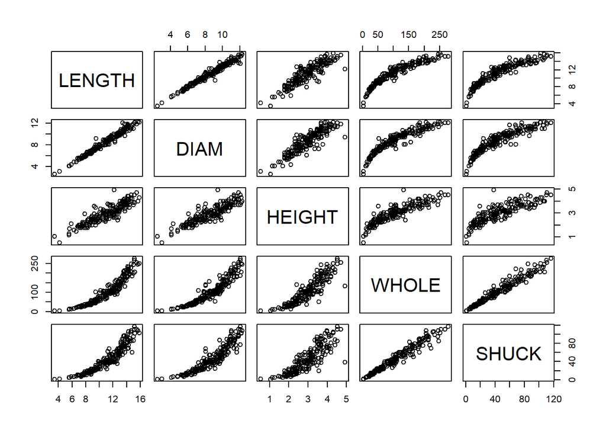

(2)(a) (1 point) Use “mydata” to plot WHOLE versus VOLUME. Color code data points by CLASS.

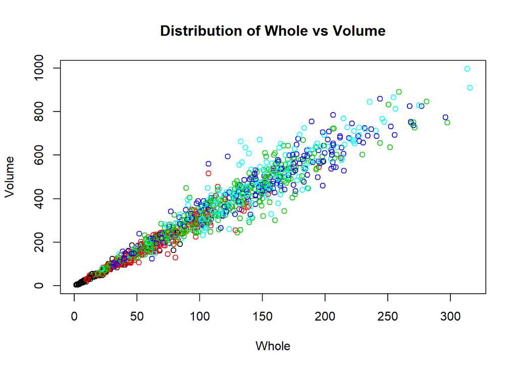

**Question (2 points): What does the wedge-shaped scatter of data points suggest about the relationship between WHOLE and VOLUME? Interpret this plot taking into account abalone physical measurements of length, diameter and heigth and the displays shown in (1)(c).**

*Answer: The interpretation being that, as an abalone’s whole weight were to increase, the volume would tend to increase more rapidly. Since volume was calculated as LENGTH* DIAM * HEIGHT, that would indicate that one, two or all of these variables increase faster relative to an abalone’s weight increase. *

(2)(b) (2 points) Use “mydata” to plot SHUCK versus WHOLE with WHOLE on the horizontal axis. Use a different color for each age class. As an aid to interpretation, determine the maximum value of the ratio of SHUCK to WHOLE. Add to the chart a straight line with zero intercept using this maximum value as the slope of the line. If you are using the ‘base R’ *plot()* function, you may use *abline()* to add this line to the plot. Use *help(abline)* in R to determine the coding for the slope and intercept arguments in the functions. If you are using ggplot2 for visualizations, *geom_abline()* should be used.

[figure not shown]

```
## integer(0)
```

**Question (2 points): How does the variability in this plot differ from the plot in (a)? Compare the two displays. Keep in mind that SHUCK is a part of WHOLE.**

*Answer: The variablility differ from volume vs whole weight and shuck (meat) vs whole weight tend to have differences as we move farther along the x axis on the two graphs. In the first graph, there tends to be more variability, meaning more skewness of volume relative to whole weight. In the second graph, the data seems to stay more concise as we measure the shuck(meat) weight as we analyze the increase in whole weight.*

(3)(a) (2 points) Use “mydata” to create a multi-figured plot with histograms, boxplots and Q-Q plots of RATIO differentiated by sex. This can be done using *par(mfrow = c(3,3))* and base R or *grid.arrange()* and ggplot2. The first row would show the histograms, the second row the boxplots and the third row the Q-Q plots. Be sure these displays are legible.

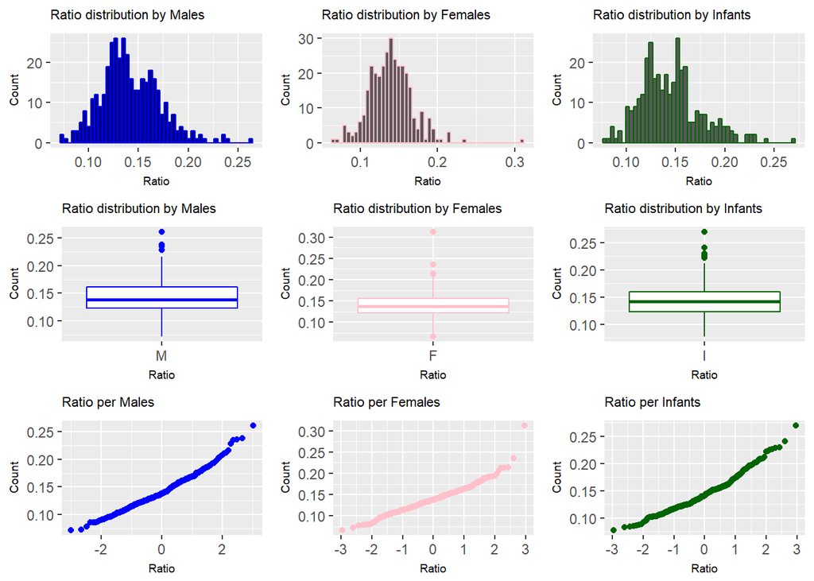

**Question (2 points): Compare the displays. How do the distributions compare to normality? Take into account the criteria discussed in the sync sessions.**

(3)(b) (2 points) Use the boxplots to identify RATIO outliers. Present the abalones with these outlying RATIO values along with their associated variables in “mydata.” Hint: Construct a listing of the observations using the kable() function.

|  | SEX | LENGTH | DIAM | HEIGHT | WHOLE | SHUCK | RINGS | CLASS | VOLUME | RATIO |
| --- | --- | --- | --- | --- | --- | --- | --- | --- | --- | --- |
| 3 | I | 10.080 | 7.350 | 2.205 | 79.37500 | 44.00000 | 6 | A1 | 163.364040 | 0.2693371 |
| 37 | I | 4.305 | 3.255 | 0.945 | 6.18750 | 2.93750 | 3 | A1 | 13.242072 | 0.2218308 |
| 42 | I | 2.835 | 2.730 | 0.840 | 3.62500 | 1.56250 | 4 | A1 | 6.501222 | 0.2403394 |
| 58 | I | 6.720 | 4.305 | 1.680 | 22.62500 | 11.00000 | 5 | A1 | 48.601728 | 0.2263294 |
| 67 | I | 5.040 | 3.675 | 0.945 | 9.65625 | 3.93750 | 5 | A1 | 17.503290 | 0.2249577 |
| 89 | I | 3.360 | 2.310 | 0.525 | 2.43750 | 0.93750 | 4 | A1 | 4.074840 | 0.2300704 |
| 105 | I | 6.930 | 4.725 | 1.575 | 23.37500 | 11.81250 | 7 | A2 | 51.572194 | 0.2290478 |
| 200 | I | 9.135 | 6.300 | 2.520 | 74.56250 | 32.37500 | 8 | A2 | 145.027260 | 0.2232339 |
| 350 | F | 7.980 | 6.720 | 2.415 | 80.93750 | 40.37500 | 7 | A2 | 129.505824 | 0.3117620 |
| 420 | F | 11.550 | 7.980 | 3.465 | 150.62500 | 68.55375 | 10 | A3 | 319.365585 | 0.2146560 |
| 458 | F | 11.445 | 8.085 | 3.150 | 139.81250 | 68.49062 | 9 | A3 | 291.478399 | 0.2349767 |
| 586 | F | 12.180 | 9.450 | 4.935 | 133.87500 | 38.25000 | 14 | A5 | 568.023435 | 0.0673388 |
| 746 | M | 13.440 | 10.815 | 1.680 | 130.25000 | 63.73125 | 10 | A3 | 244.194048 | 0.2609861 |
| 754 | M | 10.500 | 7.770 | 3.150 | 132.68750 | 61.13250 | 9 | A3 | 256.992750 | 0.2378764 |
| 803 | M | 10.710 | 8.610 | 3.255 | 160.31250 | 70.41375 | 9 | A3 | 300.153640 | 0.2345924 |
| 810 | M | 12.285 | 9.870 | 3.465 | 176.12500 | 99.00000 | 10 | A3 | 420.141472 | 0.2356349 |
| 852 | M | 11.550 | 8.820 | 3.360 | 167.56250 | 78.27187 | 10 | A3 | 342.286560 | 0.2286735 |
| 870 | M | 11.445 | 8.610 | 2.520 | 99.12500 | 53.70750 | 9 | A3 | 248.324454 | 0.2162795 |

**Question (2 points): What are your observations regarding the results in (3)(b)?**

(4)(a) (3 points) With “mydata,” display two separate sets of side-by-side boxplots for VOLUME and WHOLE differentiated by CLASS (Davies Section 14.3.2). Show five boxplots for VOLUME in one display and five boxplots for WHOLE (making two separate displays). Also, create two separate scatterplots of VOLUME and WHOLE versus RINGS. Present these displays in one graphic, the boxplots in one row and the scatterplots in a second row. Base R or ggplot2 may be used.

[figure not shown]

**Question (5 points) How well do you think these variables would perform as predictors of age?**

*Answer: I do not thin too well, The reason being is that as more rings are present in abalones, volume and whole weight tend to be more variable, meaning it is not concise enough to make predictions out of. For instance, in classes A3 and A4, the data supporting volume and whole weight is spread across the graphs, not showing any indication that there is consistency of whole weight and volume by age.*

(5)(a) (2 points) Use *aggregate()* with “mydata” to compute the mean values of VOLUME, SHUCK and RATIO for each combination of SEX and CLASS. Then, using *matrix()*, create matrices of the mean values. Using the “dimnames” argument within *matrix()* or the *rownames()* and *colnames()* functions on the matrices, label the rows by SEX and columns by CLASS. Present the three matrices (Kabacoff Section 5.6.2, p. 110-111). You do not need to be concerned with the number of digits presented.

[output not shown]

[output not shown]

[output not shown]

(5)(b) (3 points) Present three graphs. Each graph should be generated with three separate lines appearing, one for each sex. The first should show mean RATIO versus CLASS; the second, average VOLUME versus CLASS; the third, SHUCK versus CLASS. This may be done with the ‘base R’ *interaction.plot()* function or with ggplot2.

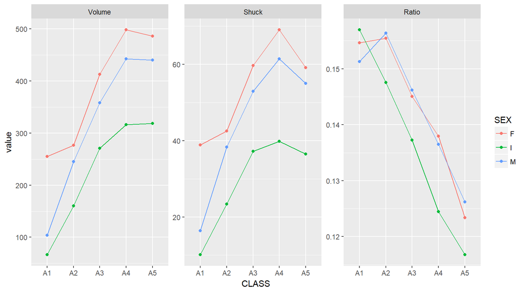

**Question (2 points): What questions do these plots raise? Discuss.**

*Answer: Why is there a an increase in volume and shuck from classes A1 to A4, but in class A5 volume is leveled off and shuck decreases? Why do females have more volume and shuck than compared to men? Why do infants have higher ratio than males and females in class A1 but then has less ratio than males and females in the other classes?*

5(c) (3 points) Present four different boxplot displays using *par(mfrow = c(2, 2)*. The first line would show VOLUME by RINGS for the infants and the adults (factor levels “M” and “F” combined), The second line would show WHOLE by RINGS for the infants and the adults (factor levels “M” and “F” combined). Since the data are sparse beyond 15 rings, limit the displays to less than 16 rings. Use ylim = c(0,1100) for VOLUME and ylim = c(0, 400) for WHOLE. If you wish to reorder the displays for presentation purposes or use ggplot2 go ahead.

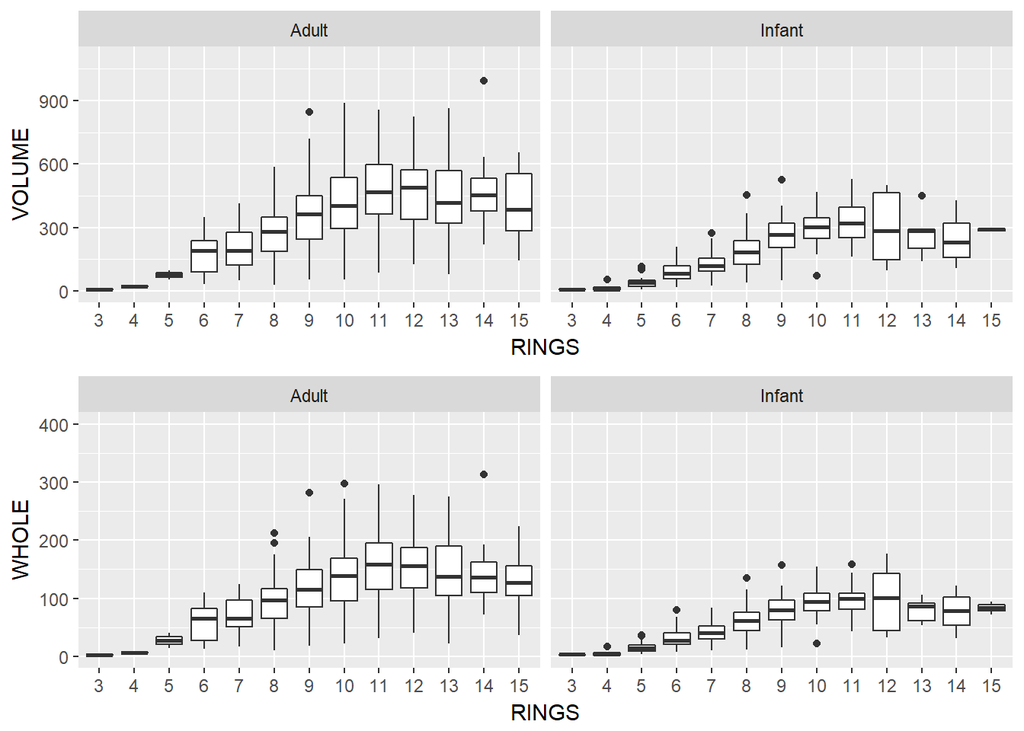

**Question (2 points): Abalone growth is said to decline when they have more than ten rings. Do you see trends in these plots to support this statement?**

**Conclusions**

Please respond to each of the following questions (8 points total):

**Question 1) (5 points) What are plausible reasons that explain the failure of the original study? Consider to what extent abalone physical measurements may be used for predicting age.**

**Question 2) (3 points) Setting the abalone data and analysis aside, if you were presented with an overall histogram and summary statistics from a sample and no other information, what questions might you ask before accepting them as representative of the sampled population?**

*Answer: My first question would be is to ask if we know what an estimated population is of abalones? If there are 100 million abalones in the world, then a sample of 1000 seems very small to help predict the age of an abalone. My next question would be is what metrics are being shown in the overall histogram? What metrics will the histogram be providing me? Another quesiton I may have is how did the summary statistics get derived to the output? Was there noised removed from the analysis? If I was given the data without any information, I would want to know more about the research and why the research was conducted. I would also know what the desired outcome would be fore the analysis.*

**Question 3) (2 points) What do you see as difficulties when drawing conclusions from observational studies? Can causality be determined? What might be learned from such studies?**

*Answer: The biggest fear from observational studies is drawing a conclusion, without enough analysis, that an event causes an outcome, but in reality it in fact didn’t. Observational studies can have huge consequences of providing information that may vary well in fact not be as accurate as originally thought out. Explanatory variables could have lurking variables that could make an analysis successful or not, but the person doing the analysis may miss that lurking variable when conducting research. Causality CAN be determined, if all or most the response and lurking variables are taken into consideration and the data is consice, clean, and there is enough of it. Observational studies, personally, help paint a better picture of what the data is saying. Without having to go through thousands of records of data, I can present it in a way where it’s easy to see, depict, and analyze further. That on it’s own helps me better understand the event that I am analyzing to make sure that what I am trying to research makes sense and that I have all the data I need. If and when I have sufficient data to try and predict certain events, I get a better sense of estimating outcomes.*